# The forecaster’s toolbox

## Transformation and adjustments

1. calendar adjustments
2. population adjustments
3. Inflation adjustments
4. Mathematical transformations

### Calendar adjustments

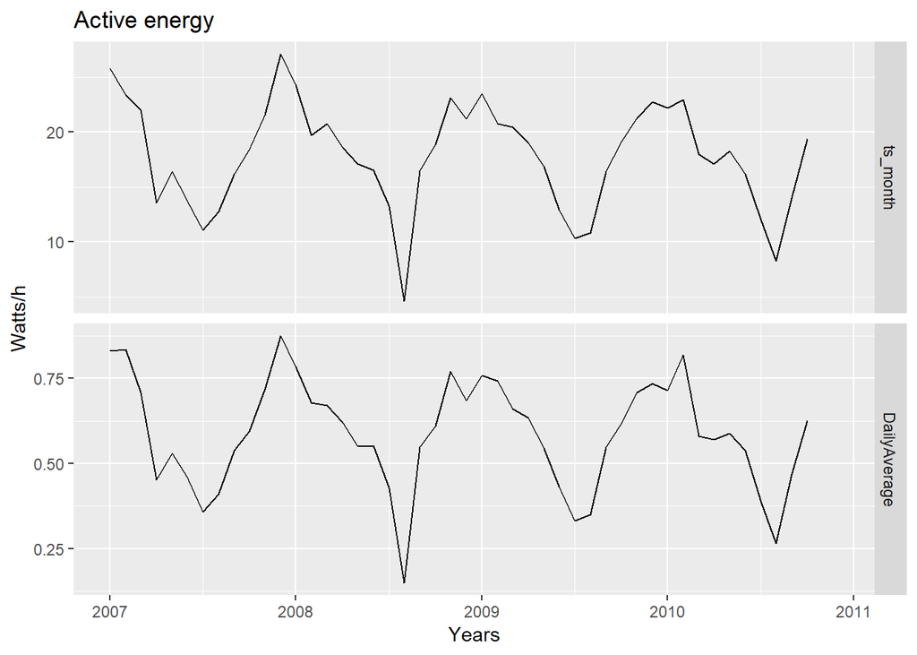

```r
# Some of the variation seen in seasonal data may be due to simple calendar effects. In such cases, it is usually much easier to remove the variation before fitting a forecasting model. The monthdays() function will compute the number of days in each month or quarter.

data %>%
  mutate(year = year(date), month = month(date, label = T, locale = "us")) %>% group_by(year, month) %>%
  summarise(mean = mean(ActiveEnergy)) -> data2

ts_month <- ts(data2[,3], start = 2007, frequency = 12)

ts_month_norm <- cbind(ts_month,
                       DailyAverage = ts_month/monthdays(ts_month))
autoplot(ts_month_norm, facet=TRUE) +
  xlab("Years") + ylab("Watts/h") +
  ggtitle("Active energy")
```

### Mathematical tranformations

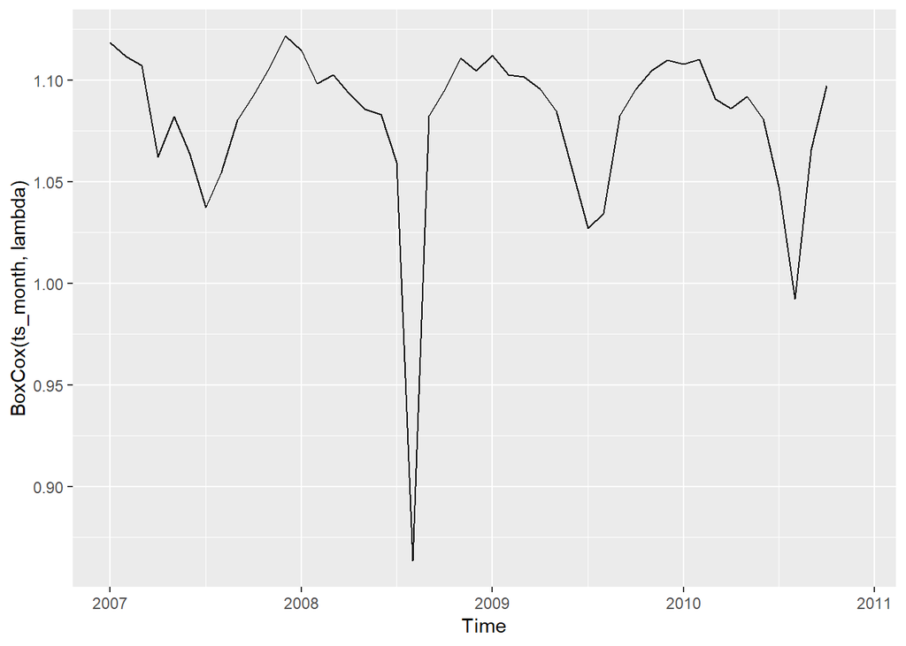

```r
# Mathematical transformations
lambda <- BoxCox.lambda(ts_month)
autoplot(BoxCox(ts_month, lambda))
```

## Residual diagnosis

Proporties of the residuals:

1. The residuals are uncorrelated. If there are correlations between residuals, then there is information left in the residuals which should be used in computing forecasts.
2. The residuals have zero mean. If the residuals have a mean other than zero, then the forecasts are biased.

Any forecasting method that does not satisfy these properties can be improved. Also has the following properties:

3. The residuals have constant variance.
4. The residuals are normally distributed.

### Example non seasonal data

For stock market prices and indexes, the best forecasting method is often the naïve method.

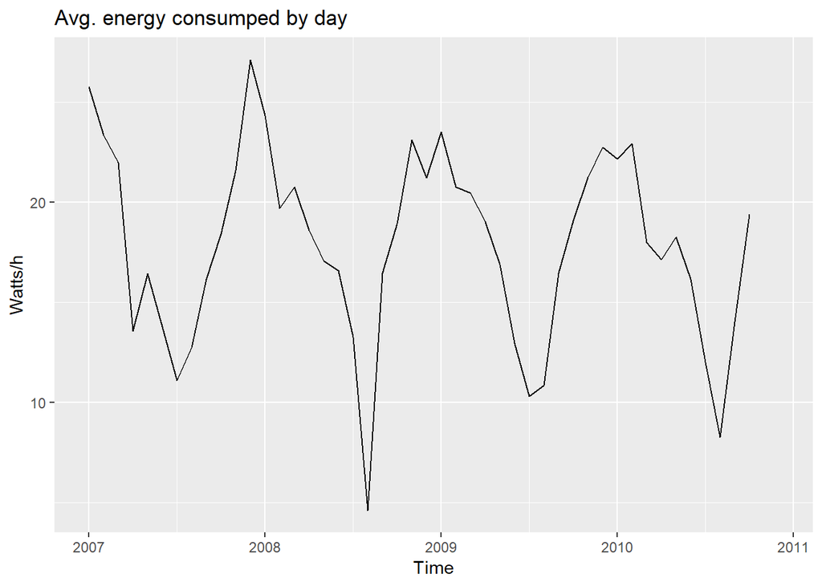

```r
t <- ts_month
autoplot(t) +
  xlab("Time") + ylab("Watts/h") +
  ggtitle("Avg. energy consumped by day")
```

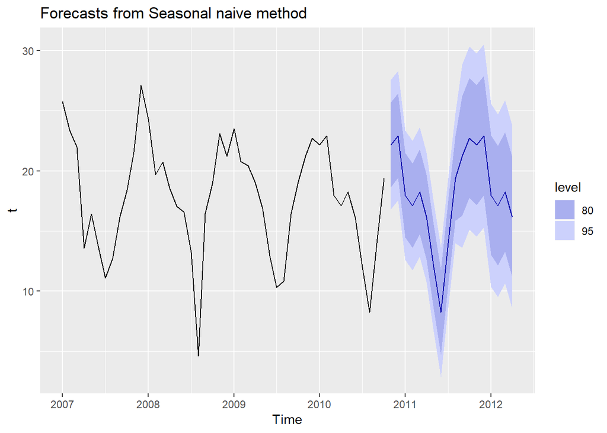

```r
autoplot(snaive(t, h = 18))
```

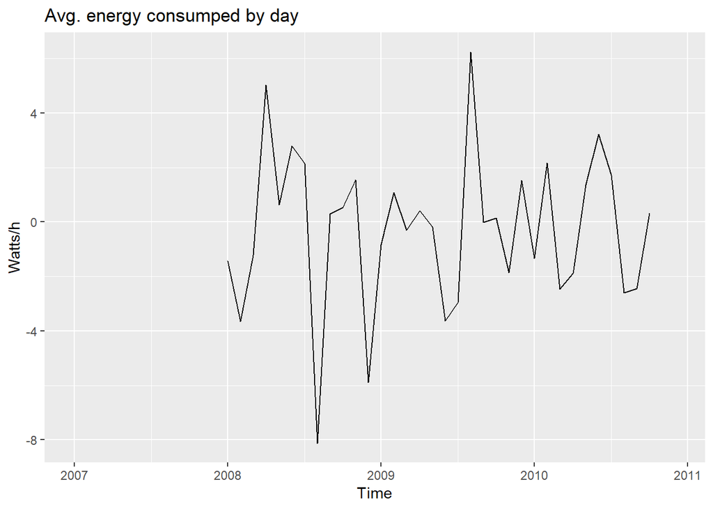

```r
res <- residuals(snaive(t, h = 18))
autoplot(res) +
  xlab("Time") + ylab("Watts/h") +
  ggtitle("Avg. energy consumped by day")
```

Understanding the errors distribution through histograms:

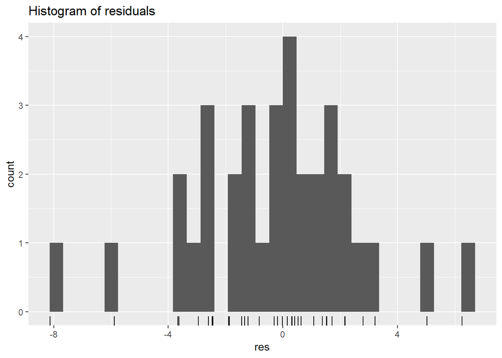

```r
gghistogram(res, bins = 30) + ggtitle("Histogram of residuals")
```

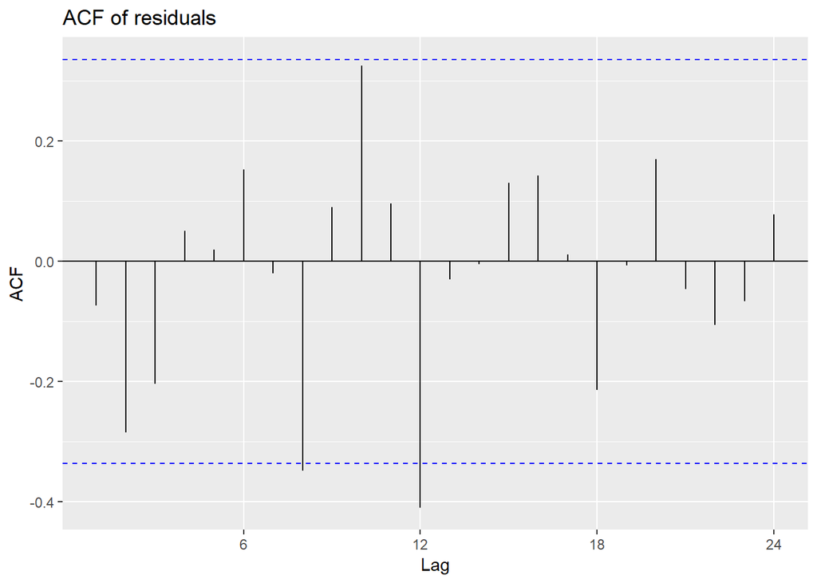

```r
ggAcf(res) + ggtitle("ACF of residuals")
```

### Using Portmanteau tests for autocorrelation

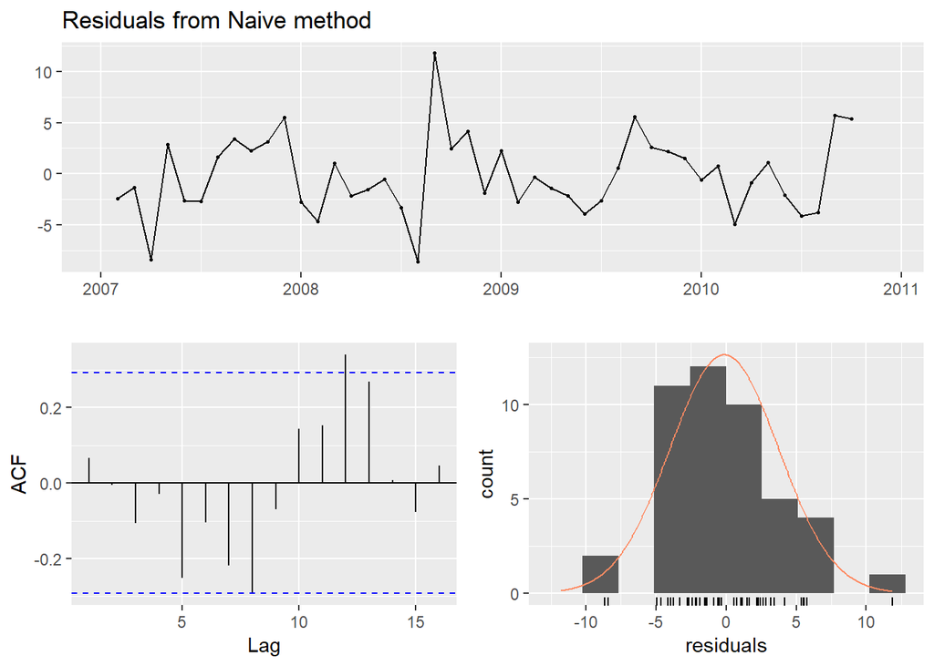

```
##
##  Ljung-Box test
##
## data:  Residuals from Naive method
## Q* = 12.517, df = 9.6, p-value = 0.2244
##
## Model df: 0.   Total lags used: 9.6
```

```r
checkresiduals(naive(t))
```

## Training and tests sets

The size of the test set is typically about 20% of the total sample, although this value depends on how long the sample is and how far ahead you want to forecast. The test set should ideally be at least as large as the maximum forecast horizon required. The following points should be noted.

- A model which fits the training data well will not necessarily forecast well.
- A perfect fit can always be obtained by using a model with enough parameters.
- Over-fitting a model to data is just as bad as failing to identify a systematic pattern in the data.

Functions to subset time series:

- window:

```r
window(t, start = 2010)
```

```
##            Jan       Feb       Mar       Apr       May       Jun       Jul
## 2010 22.169825 22.929773 17.979353 17.121190 18.254331 16.159500 12.017530
##            Aug       Sep       Oct       Nov       Dec
## 2010  8.252454 14.008265 19.389544        NA        NA
```

- subset:

```r
subset(t, start = length(t)-4*5) # select 1/5 of the data
```

[output not shown]

Or using subset function to extract values for a specific month, for the whole years:

```r
subset(t, month = 1)
```

```
## Time Series:
## Start = 2007
## End = 2010
## Frequency = 1
## [1] 25.76608 24.33146 23.50284 22.16982
```

- head and tail()

```r
tail(t, 4*5)
```

[output not shown]

### Forecast errors

We can measure forecast accuracy by summarising the forecast errors in different ways:

#### Scale-dependent errors

The two most commonly used scale-dependent measures are based on the absolute errors or squared errors:

- Mean absolute error: MAE
- Root mean squared error: RMSE

When comparing forecast methods applied to a single time series, or to several time series with the same units, the MAE is popular as it is easy to both understand and compute. A forecast method that minimises the MAE will lead to forecasts of the median, while minimising the RMSE will lead to forecasts of the mean. Consequently, the RMSE is also widely used, despite being more difficult to interpret.

#### Percentage errors

Percentage errors have the advantage of being unit-free, and so are frequently used to compare forecast performances between data sets. The most commonly used measure is:

- Mean absolute percentage error: MAPE

Another problem with percentage errors that is often overlooked is that they assume the unit of measurement has a meaningful zero.2 For example, a percentage error makes no sense when measuring the accuracy of temperature forecasts on either the Fahrenheit or Celsius scales, because temperature has an arbitrary zero point.

They also have the disadvantage that they put a heavier penalty on negative errors than on positive errors. This observation led to the use of the so-called “symmetric” MAPE (sMAPE) proposed by Armstrong (1978, p. 348), which was used in the M3 forecasting competition. It is defined by:

- sMAPE

Hyndman & Koehler (2006) recommend that the sMAPE not be used. It is included here only because it is widely used, although we will not use it in this book.

#### Scaled errors

The mean absolute scaled error is simply MASE.

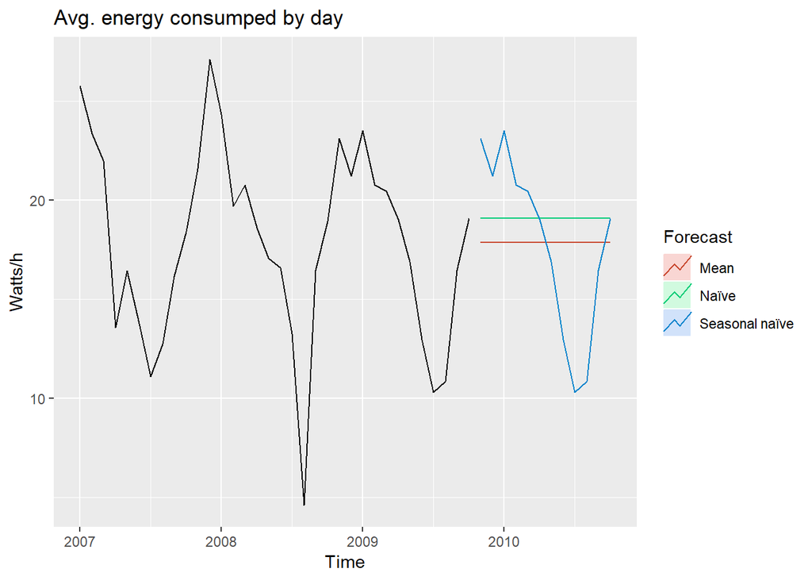

```r
t2 <- window(t,start=2007,end=c(2009,10))
fit1 <- meanf(t2,h=12)
fit2 <- rwf(t2,h=12)
fit3 <- snaive(t2,h=12)
autoplot(window(t2, start=2007)) +
  autolayer(fit1, series="Mean", PI=FALSE) +
  autolayer(fit2, series="Naïve", PI=FALSE) +
  autolayer(fit3, series="Seasonal naïve", PI=FALSE) +
  xlab("Time") + ylab("Watts/h") +
  ggtitle("Avg. energy consumped by day") +
  guides(colour=guide_legend(title="Forecast"))
```

Let’s see the metric results:

```r
t3 <- window(t, start=c(2009,10))
accuracy(fit1, t3) # meanf
```

```
##                         ME     RMSE      MAE        MPE     MAPE     MASE
## Training set  4.178707e-16 4.850178 3.905493 -12.472991 29.50353 1.749137
## Test set     -1.558625e-01 4.346520 3.454916  -9.715814 24.74521 1.547339
##                  ACF1 Theil's U
## Training set 0.627075        NA
## Test set     0.684189  1.148024
```

```r
accuracy(fit2, t3) # rwf, drift method
```

```
##                      ME     RMSE      MAE        MPE     MAPE     MASE
## Training set -0.2027798 4.016212 3.203002  -6.767606 23.11210 1.434515
## Test set     -1.3854828 4.559332 3.569147 -17.275965 27.06562 1.598499
##                   ACF1 Theil's U
## Training set 0.0101406        NA
## Test set     0.6841890  1.311989
```

```r
accuracy(fit3, t3) # snaïve
```

```
##                      ME     RMSE      MAE       MPE     MAPE     MASE
## Training set -0.3349653 3.173292 2.232812 -7.107118 19.91836 1.000000
## Test set     -0.1901179 2.040239 1.909356 -2.416201 12.33420 0.855135
##                      ACF1 Theil's U
## Training set -0.087967542        NA
## Test set     -0.003252463 0.5074155
```

#### Non seasonal example

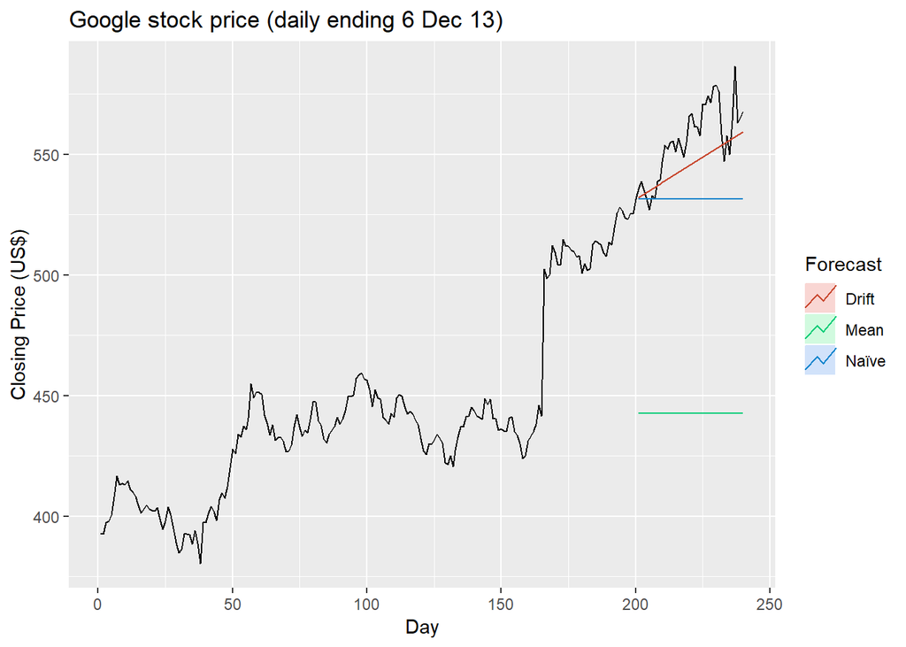

```r
googfc1 <- meanf(goog200, h=40)
googfc2 <- rwf(goog200, h=40)
googfc3 <- rwf(goog200, drift=TRUE, h=40)
autoplot(subset(goog, end = 240)) +
  autolayer(googfc1, PI=FALSE, series="Mean") +
  autolayer(googfc2, PI=FALSE, series="Naïve") +
  autolayer(googfc3, PI=FALSE, series="Drift") +
  xlab("Day") + ylab("Closing Price (US$)") +
  ggtitle("Google stock price (daily ending 6 Dec 13)") +
  guides(colour=guide_legend(title="Forecast"))
```

```r
googtest <- window(goog, start=201, end=240)
accuracy(googfc1, googtest)
```

```
##                         ME      RMSE       MAE        MPE     MAPE
## Training set -4.296286e-15  36.91961  26.86941 -0.6596884  5.95376
## Test set      1.132697e+02 114.21375 113.26971 20.3222979 20.32230
##                   MASE      ACF1 Theil's U
## Training set  7.182995 0.9668981        NA
## Test set     30.280376 0.8104340  13.92142
```

```r
accuracy(googfc2, googtest)
```

```
##                      ME      RMSE       MAE       MPE      MAPE     MASE
## Training set  0.6967249  6.208148  3.740697 0.1426616 0.8437137 1.000000
## Test set     24.3677328 28.434837 24.593517 4.3171356 4.3599811 6.574582
##                     ACF1 Theil's U
## Training set -0.06038617        NA
## Test set      0.81043397  3.451903
```

```r
accuracy(googfc3, googtest)
```

```
##                        ME      RMSE       MAE         MPE      MAPE
## Training set 4.653165e-13  6.168928  3.824406 -0.01570676 0.8630093
## Test set     1.008487e+01 14.077291 11.667241  1.77566103 2.0700918
##                  MASE        ACF1 Theil's U
## Training set 1.022378 -0.06038617        NA
## Test set     3.119002  0.64732736  1.709275
```

## Time series cross-validation

```r
e <- tsCV(goog200, rwf, drift=TRUE, h=1)
sqrt(mean(e^2, na.rm=TRUE))
```

```
## [1] 6.233245
```

```
#> [1] 6.233 # RMSE with cross validation
```

```r
sqrt(mean(residuals(rwf(goog200, drift=TRUE))^2, na.rm=TRUE))
```

```
## [1] 6.168928
```

```
#> [1] 6.169 # RMSE without cross validation
```

As expected, the RMSE from the residuals is smaller, as the corresponding “forecasts” are based on a model fitted to the entire data set, rather than being true forecasts.

A good way to choose the best forecasting model is to find the model with the smallest RMSE computed using time series cross-validation.

### Pipe operator

We can do the same thing than above but with pipes operators:

```r
goog200 %>% tsCV(forecastfunction=rwf, drift=TRUE, h=1) -> e
e^2 %>% mean(na.rm=TRUE) %>% sqrt()
```

```
## [1] 6.233245
```

```
#> [1] 6.233
```

```r
goog200 %>% rwf(drift=TRUE) %>% residuals() -> res
res^2 %>% mean(na.rm=TRUE) %>% sqrt()
```

```
## [1] 6.168928
```

```
#> [1] 6.169
```

### Example: using tsCV()

The code below evaluates the forecasting performance of 1- to 8-step-ahead naïve forecasts with tsCV(), using MSE as the forecast error measure. The plot shows that the forecast error increases as the forecast horizon increases, as we would expect.

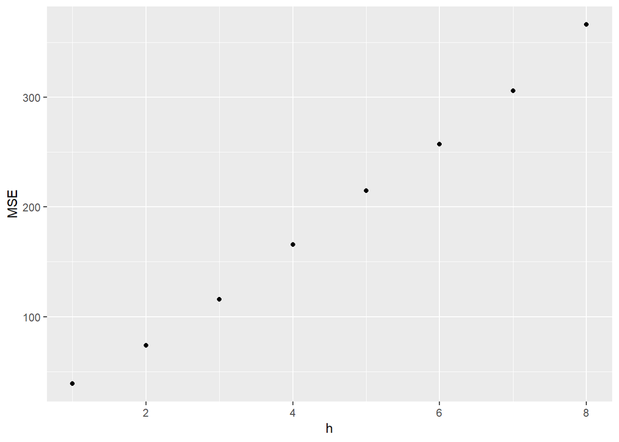

```r
e <- tsCV(goog200, forecastfunction=naive, h=8)
# Compute the MSE values and remove missing values
mse <- colMeans(e^2, na.rm = T)
# Plot the MSE values against the forecast horizon
data.frame(h = 1:8, MSE = mse) %>%
  ggplot(aes(x = h, y = MSE)) + geom_point()
```

## The forecast package in R

Main functions included into the library fpp2 (caontains the forecast package):

- meanf()
- naive(), snaive()
- rwf()
- croston()
- stlf()
- ses()
- holt(), hw()
- splinef()
- thetaf()
- forecast() -> function to produce forecasts from that model.

# Exercices

### 1. For the following series, find an appropriate Box-Cox transformation in order to stabilise the variance

##### usnetelec

###### autoplot

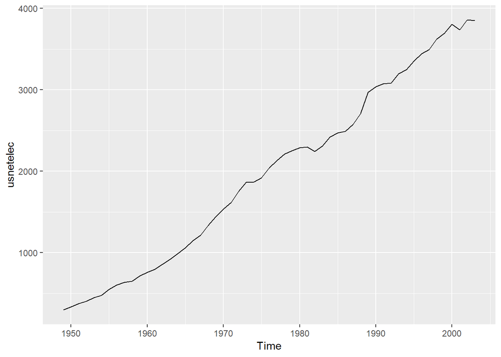

```r
autoplot(usnetelec)
```

###### autoplot with lambda to stabilise the variance

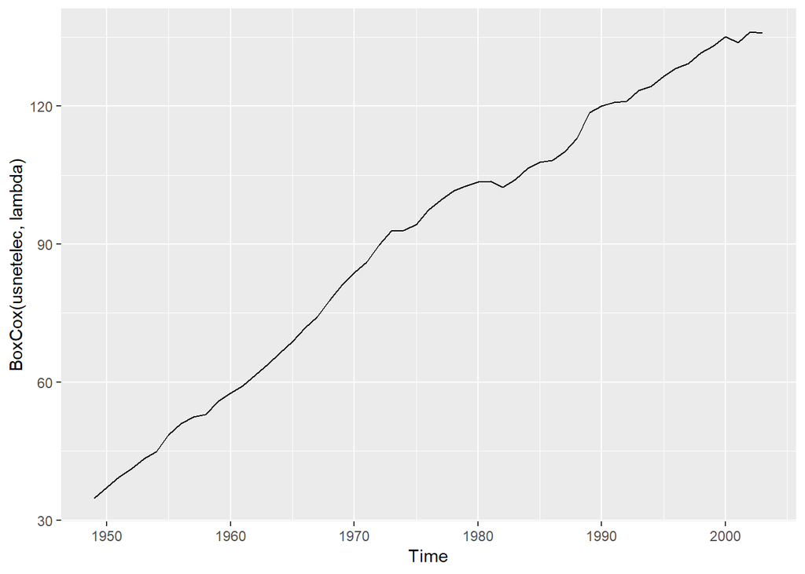

```r
# we are applying a tranformation but it doesn't need it
lambda <- BoxCox.lambda(usnetelec)
autoplot(BoxCox(usnetelec, lambda))
```

##### usgdp

###### autoplot usgdp

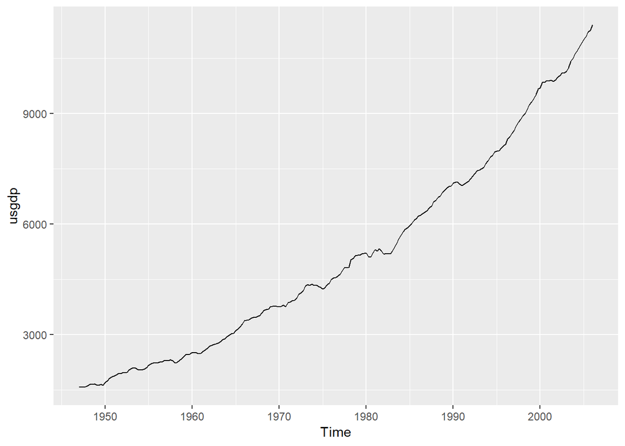

```r
autoplot(usgdp)
```

###### variance normalization with lambda

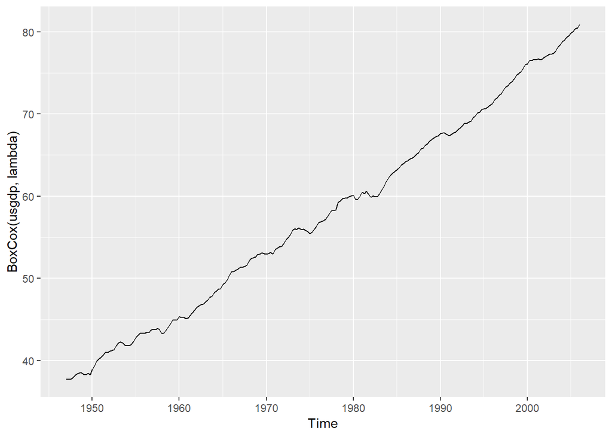

```r
# we are applying a tranformation but it doesn't need it
lambda <- BoxCox.lambda(usgdp)
autoplot(BoxCox(usgdp, lambda))
```

##### mcopper

Monthly copper prices. Copper, grade A, electrolytic wire bars/cathodes,LME,cash (pounds/ton)

###### autoplot

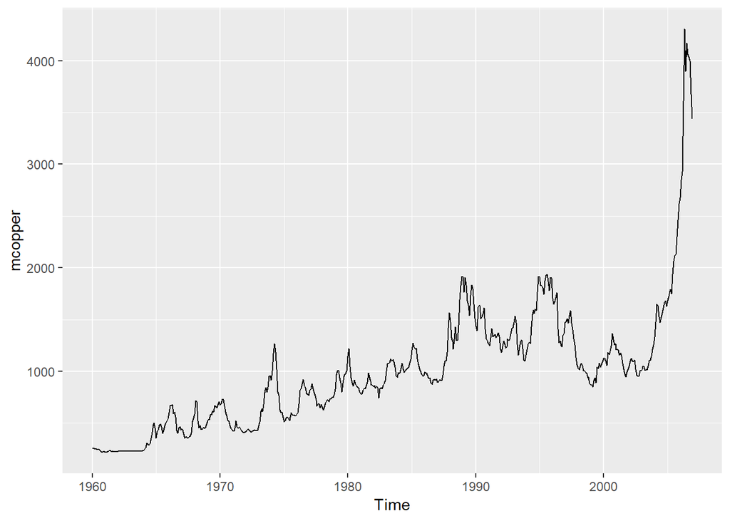

```r
autoplot(mcopper)
```

###### variance stabilization with lambda

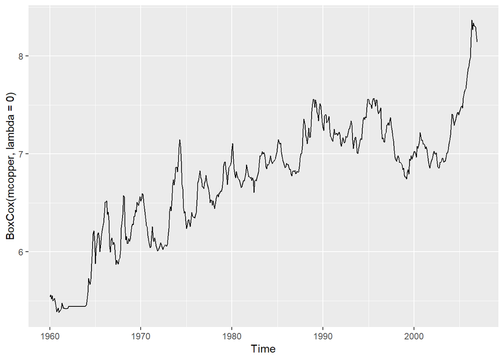

```r
lambda <- BoxCox.lambda(mcopper)
autoplot(BoxCox(mcopper, lambda = 0))
```

##### enplanements

###### autoplot

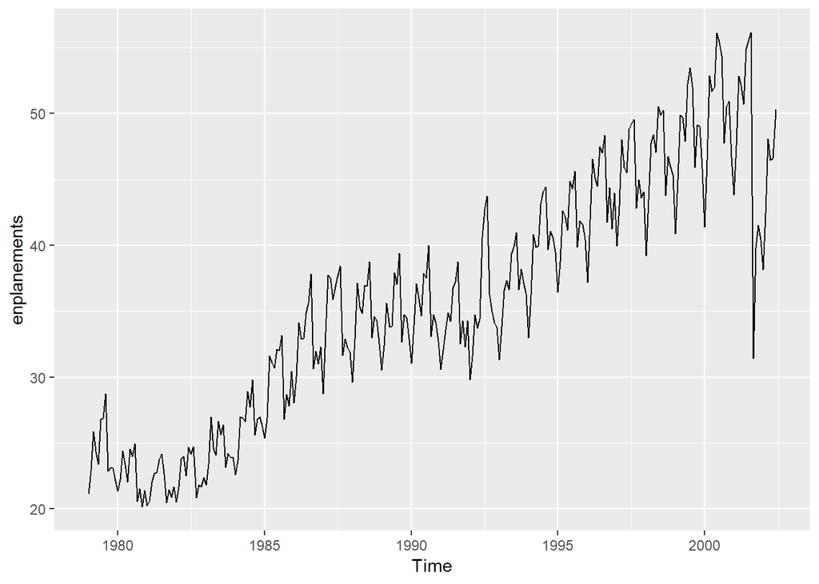

```r
autoplot(enplanements)
```

###### variance stabilization with lambda

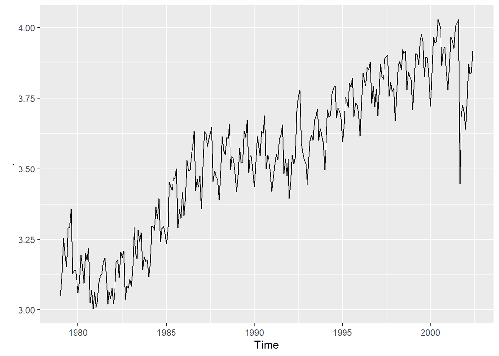

```r
# We will do a log transformation
enplanements %>% BoxCox(lambda = 0) %>% autoplot()
```

### 2. Why is a Box-Cox transformation unhelpful for the cangas data?

##### cangas dataset

cangas = Monthly Canadian gas production, billions of cubic metres, January 1960 - February 2005

###### autoplot cangas

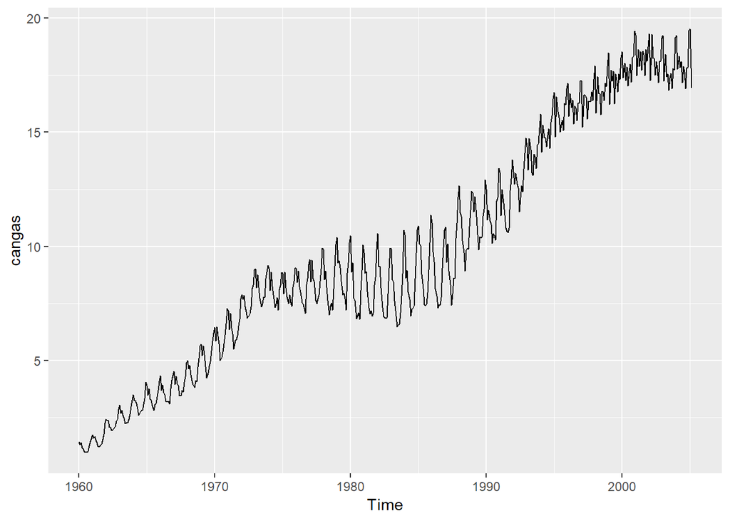

```r
autoplot(cangas)
```

###### applying lambda to deal with variance

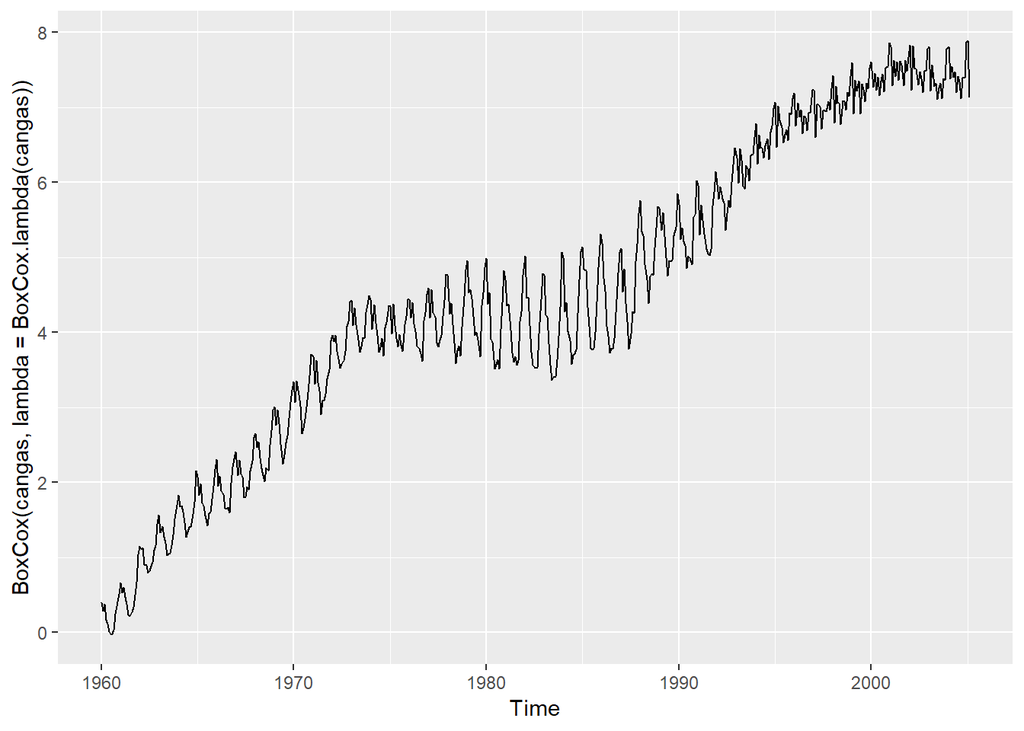

```r
autoplot(BoxCox(cangas, lambda = BoxCox.lambda(cangas)))
```

Here the variance of the series changes, but not with the level of the series. Box Cox transformations are designed to handle series where the variance increases (or decreases) with the level of the series.

### 3. What Box-Cox transformation would you select for your retail data (from Exercise 3 in Section 2.10)?

##### working with retail data

###### autplot

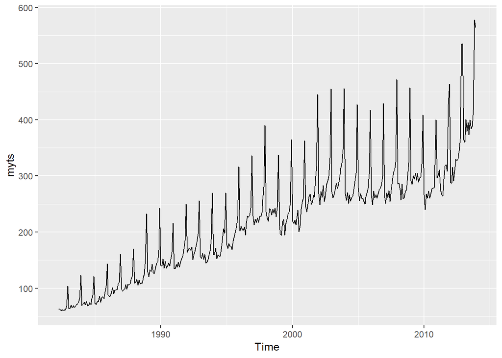

```r
retaildata <- readxl::read_xlsx("../Datasets/practice_datasets/retail.xlsx", skip = 1)
myts <- ts(retaildata[,"A3349873A"], start = c(1982,4), frequency = 12)
autoplot(myts)
```

###### checking boxcox to deal with variance

From visual inspection, a log transformation would be appropriate here. It also makes sense, as retail expenditure is likely to increase proportionally to population, and therefore the seasonal fluctuations are likely to be proportional to the level of the series. It has the added advantage of being easier to explain than some other transformations. Finally, it is relatively close to the automatically selected value of `BoxCox.lambda(myts)` = 0.1276369.

If you have selected a different series from the retail data set, you might choose a different transformation.

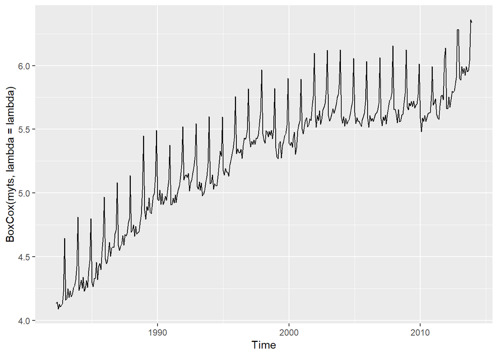

```r
lambda = 0
autoplot(BoxCox(myts, lambda = lambda))
```

### 4. For each of the following series, make a graph of the data. If transforming seems appropriate, do so and describe the effect

##### dole

###### no transformation

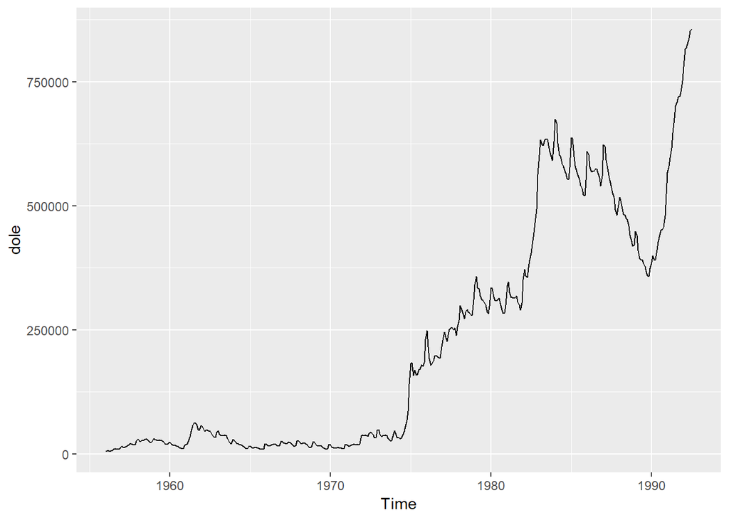

```r
autoplot(dole)
```

###### transformation

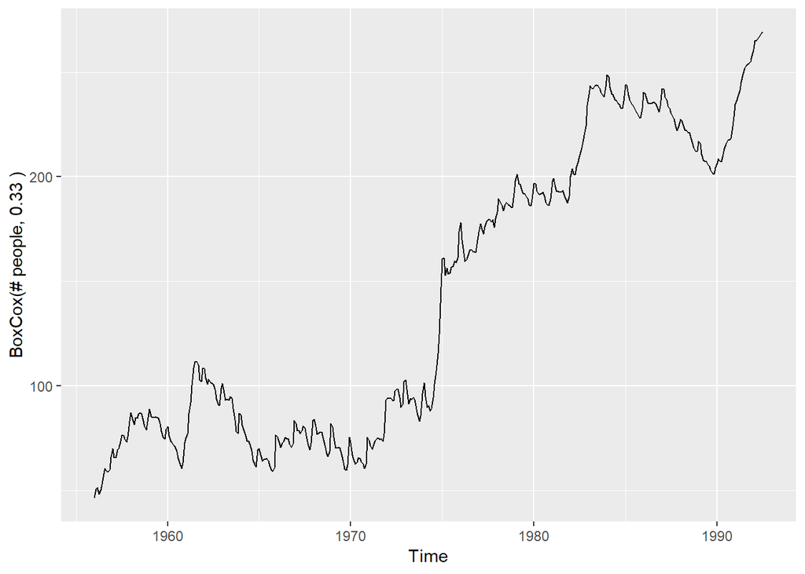

```r
lambda <- BoxCox.lambda(dole)
dole %>% BoxCox(lambda) %>% autoplot() + ylab(paste("BoxCox(# people,", round(lambda, 2), ")"))
```